# Can Geographic Data Save the World?

2017-05-02

## Contents

- Introductory comments
- An example: the propensity to cycle tool
- **dplyr** and tibbles (if time allows)
- Discussion: can GDS save the world?

## Introduction

## What is saving the world?

Many ways of saying the same thing:

- 'Policy-led research'
- 'Impact'
- 'Socially beneficial research'
- Don't be evil (Google)

My definition: **building an evidence-base for sustainable systems**.

- In the context of climate change that means:
- Building an evidence-base to transition away from fossil fuels
- But could also be interpretted in terms of other (quantifiable) social/economic/environmental indicators

## Why bother?

- If we're doomed anyway?
- > I urge everyone to read this series of tweets: it is clear that the govt is incompetent, the prime minister is deluded, & we are damned. https://t.co/aaNYvSpxK9

  > — Michael Cashman (mcashmanCBE) [April 30, 2017](https://twitter.com/mcashmanCBE/status/858821602611474432)
- > Rapid Ice Melt In East Antarctica Could Lead to 11-Foot Rise In Global Sea Level, Scientists Say https://t.co/3jYOQhyeUL [pic.twitter.com/QdTOQNC6m7](https://t.co/QdTOQNC6m7)

## Aren't the machines 'on it' anyway?

- Agency is no longer exclusively human domain
- Machine learning is "is finding commercial applications that range from self-driving cars to websites that recommend products on the basis of a user's browsing history" (Castelvecchi 2016).
- Where does the (data) scientist come in in this context?
- More important than ever to set high level aims/goals
- Autonomous vehicle analogy: robots are good at getting from A to B but not deciding where and when to travel

> Before scientists can trust AI, they first need to understand how machines learn: https://t.co/DekQuyP8YE [pic.twitter.com/Phqtj3mRc1](https://t.co/Phqtj3mRc1)

> — Nature News&Comment (NatureNews) [May 1, 2017](https://twitter.com/NatureNews/status/859112847930007552)

## What is Geographic Data Science?

- You tell me!
- How does it differ from good old 'GIS'?
- What does the science in the title mean?
- Why the focus on data rather than information

Code example:

```r
d = frame_data(
  ~Attribute, ~GIS, ~GDS,
  "Home disciplines", "Geography", "Geography, Computing, Statistics",
  "Software focus", "Graphic User Interface", "Code",
  "Reproduciblility", "Minimal", "Maximal"
)
```

## Comparing GDS with GIS

```r
knitr::kable(d)
```

| Attribute | GIS | GDS |
| --- | --- | --- |
| Home disciplines | Geography | Geography, Computing, Statistics |
| Software focus | Graphic User Interface | Code |
| Reproduciblility | Minimal | Maximal |

## Geographic data science CAN 'save the world'

### But only if it's open and scientific

Reasoning:

- Evidence inevitably gets skewed by political aims
- If the people doing the research are influenced by dominant political forces, findings will be biases for political gain (solved by independent well-funded public research).
- People doing policy relevant research watch out (regarding politicians):

> “Their very spirit undergoes a pervasive transformation,” and they finally end up as “experts at exchanging smiles, handshakes, and favors.” (Reclus 2013, original: 1898)

## Importance of open data and methods

- If the data underlying policy is hidden, it can be represented to push certain aims (solved by open data)
- If the data is 'open' but the tools are closed, results open to political influence
- Which brings us onto our next topic…

## Where will cycling uptake happen?

## Prior work (source: Lovelace et al. 2017)

| Tool | Scale | Coverage | Public access | Format of output | Levels of analysis | Software licence |
| --- | --- | --- | --- | --- | --- | --- |
| Propensity to Cycle Tool | National | England | Yes | Online map | A, OD, R, RN | Open source |
| Prioritization Index | City | Montreal | No | GIS-based | P, A, R | Proprietary |
| PAT | Local | Parts of Dublin | No | GIS-based | A, OD, R | Proprietary |
| Usage intensity index | City | Belo Horizonte | No | GIS-based | A, OD, R, I | Proprietary |
| Bicycle share model | National | England, Wales | No | Static | A, R | Unknown |
| Cycling Potential Tool | City | London | No | Static | A, I | Unknown |
| Santa Monica model | City | Santa Monica | No | Static | P, OD, A | Unknown |

## The PCT team

### "If you want to go far, go as a team"

Robin Lovelace (Lead Developer, University of Leeds)

- James Woodcock (Principal Investigator, Cambridge University)
- Anna Goodman (Lead Data Analyst, LSHTM)
- Rachel Aldred (Lead Policy and Practice, Westminster University)
- Ali Abbas (User Interface, University of Cambridge)
- Alvaro Ullrich (Data Management, University of Cambridge)
- Nikolai Berkoff (System Architecture, Independent Developer)
- Malcolm Morgan (GIS and infrastructure expert, UoL)

## The PCT in CWIS and LCWIP

Included in Cycling and Walking Infrastructure Strategy (CWIS) and the Local Cycling and Walking Infrastructure Plan (LCWIP)

[figure not shown]

## How the PCT works

Shows on the map where there is high cycling potential, for 4 scenarios of change

- Government Target
- Gender Equality
- Go Dutch
- Ebikes

## Scenario shift in desire lines

### Source: Lovelace et al. (2017)

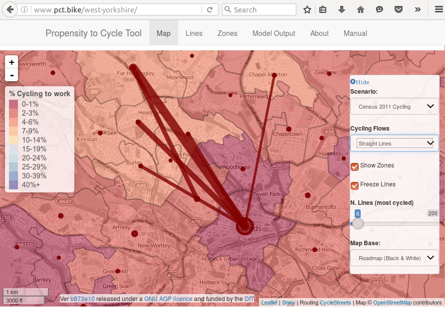

- Origin-destination data shows 'desire lines'
- How will these shift with cycling uptake

## Scenario shift in network load

[figure not shown]

### "Actions speak louder than words"

- Test version of [p](http://npct0.vs.mythic-beasts.com/m/?r=liverpool-city-region)[www.pct.bike](http://pct.bike/)

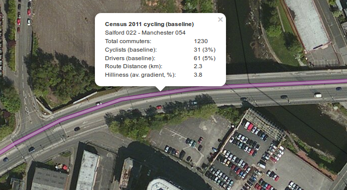

## tibbles and dplyr: A detour for programmers

## Why data carpentry?

> Data analysts and 'scientists': don't wrangle, munge or 'hack' your valuable datasets. Use [#datacarpentry](https://twitter.com/hashtag/datacarpentry?src=hash): https://t.co/gXrlIJH91R [pic.twitter.com/GSWS7O7zBz](https://t.co/GSWS7O7zBz)

> — Robin Lovelace (robinlovelace) [February 20, 2017](https://twitter.com/robinlovelace/status/833622374037721089)
- If you 'hack' or 'munge' data, it won't scale
- So ultimately it's about being able to handle Big Data
- We'll cover the basics of data frames and tibbles
- And the basics of **dplyr**, an excellent package for data carpentry
  - **dplyr** is also compatible with the **sf** package

## The data frame

The humble data frame is at the heart of most analysis projects:

```r
d = data.frame(x = 1:3, y = c("A", "B", "C"))
d
```

```
##   x y
## 1 1 A
## 2 2 B
## 3 3 C
```

In reality this is a list, making function work on each column:

```r
summary(d)
```

```
##        x       y
##  Min.   :1.0   A:1
##  1st Qu.:1.5   B:1
##  Median :2.0   C:1
##  Mean   :2.0
##  3rd Qu.:2.5
##  Max.   :3.0
```

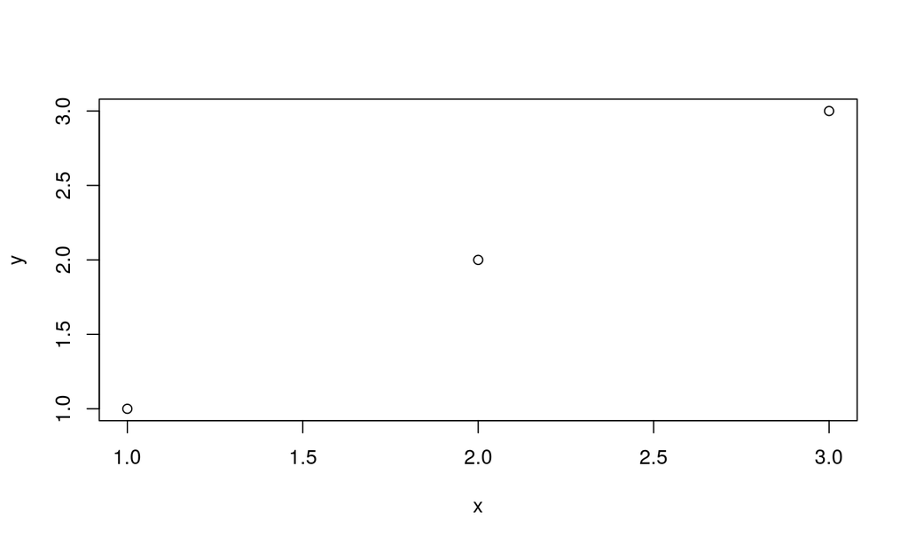

```r
plot(d)
```

## Subsetting

In base R, there are many ways to subset:

```r
d[1,] # the first line
```

```
##   x y
## 1 1 A
```

```r
d[,1] # the first column
```

```
## [1] 1 2 3
```

```r
d$x # the first column
```

```
## [1] 1 2 3
```

```r
d [1] # the first column, as a data frame
```

```
##   x
## 1 1
## 2 2
## 3 3
```

## The tibble

Recently the data frame has been extended:

```r
library("tibble")
dt = tibble(x = 1:3, y = c("A", "B", "C"))
dt
```

```
## # A tibble: 3 × 2
##       x     y
##   <int> <chr>
## 1     1     A
## 2     2     B
## 3     3     C
```

## Advantages of the tibble

It comes down to efficiency and usability

- When printed, the tibble diff reports class
- Character vectors are not coerced into factors
- When printing a tibble diff to screen, only the first ten rows are displayed

## dplyr

Like tibbles, has advantages over historic ways of doing things

- Type stability (data frame in, data frame out)
- Consistent functions - functions not `[` do everything
- Piping make complex operations easy

```r
ghg_ems %>%
  filter(!grepl("World|Europe", Country)) %>%
  group_by(Country) %>%
  summarise(Mean = mean(Transportation),
            Growth = diff(range(Transportation))) %>%
  top_n(3, Growth) %>%
  arrange(desc(Growth))
```

```r
# dplyr must be loaded with
library(dplyr)
```

## Why pipes?

```r
wb_ineq %>%
  filter(grepl("g", Country)) %>%
  group_by(Year) %>%
  summarise(gini = mean(gini, na.rm  = TRUE)) %>%
  arrange(desc(gini)) %>%
  top_n(n = 5)
```

vs

```r
top_n(
  arrange(
    summarise(
      group_by(
        filter(wb_ineq, grepl("g", Country)),
        Year),
      gini = mean(gini, na.rm  = TRUE)),
    desc(gini)),
  n = 5)
```

## Subsetting with dplyr

Only 1 way to do it, making life simpler:

```r
select(dt, x) # select columns
```

```
## # A tibble: 3 × 1
##       x
##   <int>
## 1     1
## 2     2
## 3     3
```

```r
slice(dt, 2) # 'slice' rows
```

```
## # A tibble: 1 × 2
##       x     y
##   <int> <chr>
## 1     2     B
```

## How we've used this in the PCT

## Worked example: pct data in West Yorksire

- We'll download and visualise some transport data

```r
u_pct = "https://github.com/npct/pct-data/raw/master/west-yorkshire/l.Rds"
if(!file.exists("l.Rds"))
  download.file(u_pct, "l.Rds")
library(stplanr)
```

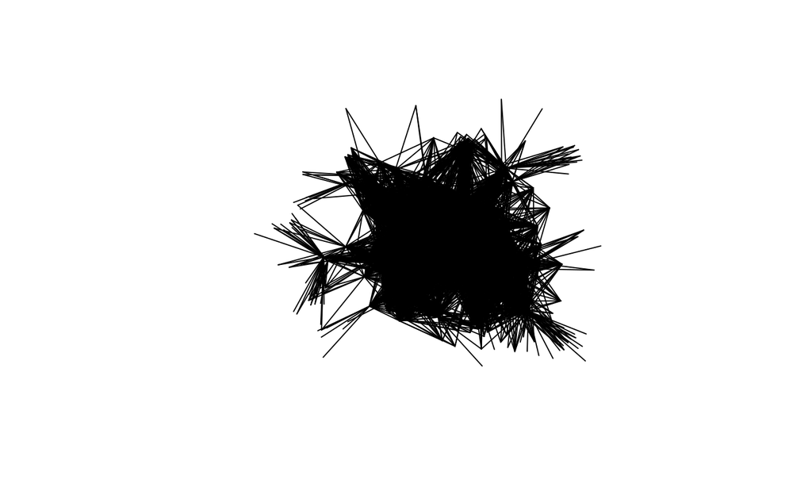

```r
l = readRDS("l.Rds")
plot(l)
```

## Analysing where people walk

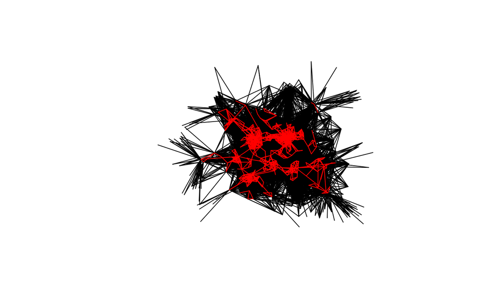

```r
sel_walk = l$foot > 9
l_walk = l[sel_walk,]
plot(l)
plot(l_walk, add = T, col = "red")
```

```r
library(dplyr) # for next slide...
```

## Doing it with sf (!)

```r
l_walk1 = l %>% filter(All > 10) # fails
```

```r
library(sf)
```

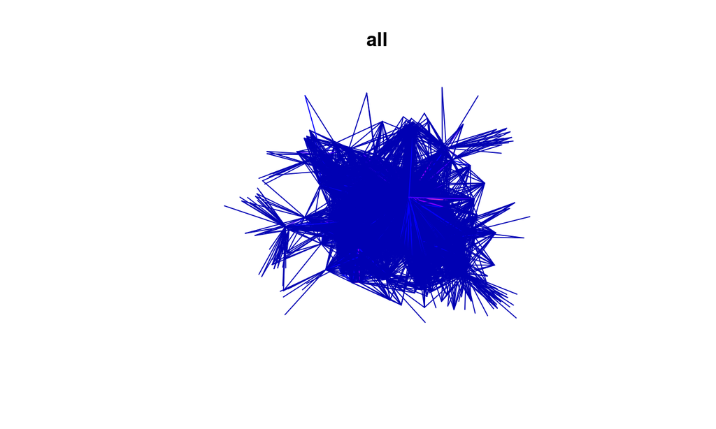

```r
l_sf = st_as_sf(l)
plot(l_sf[6])
```

## Subsetting with sf

### much easier

```r
l_walk2 = l_sf %>%
  filter(foot > 9)
plot(l_sf[6])
plot(l_walk2, add = T)
```

## Subsetting with sf

### results

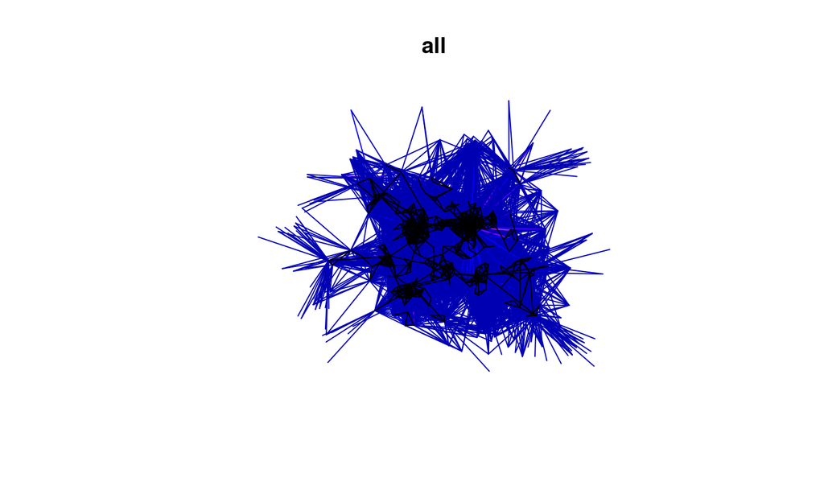

## A more advanced example

```r
l_sf$distsf = as.numeric(st_length(l_sf))
l_drive_short2 = l_sf %>%
  filter(distsf < 1000) %>%
  filter(car_driver > foot)
```

```r
library(tmap)
tmap_mode("view")
```

```
## tmap mode set to interactive viewing
```

```r
qtm(l_drive_short2)
```

[interactive chart not shown]

## Discussion: ensuring research is used for the greater good

## Points of discussion

It is clear that geographical research can have large policy impacts.

- That researchers can act to maximise the social benefit of the research
- That involves getting the evidence out to as many people as possible
- And using open source, accessible tools - the 'science' in GDS?

But many questions remain:

- Where to draw the line between impartial research and campaigning?
- To what extent should researchers open-sourcing their work defend against commercial exploitation?

## Final question

- What can you do to maximise the social benefits arising from your work?
- Thanks for listening - get in touch via `r.lovelace@leeds.ac.uk` or `@robinlovelace`

## References

Castelvecchi, Davide. 2016. “Can We Open the Black Box of AI?” *Nature News* 538 (7623): 20. doi:10.1038/538020a.

Lovelace, Robin, Anna Goodman, Rachel Aldred, Nikolai Berkoff, Ali Abbas, and James Woodcock. 2017. “The Propensity to Cycle Tool: An Open Source Online System for Sustainable Transport Planning.” *Journal of Transport and Land Use* 10 (1). doi:10.5198/jtlu.2016.862.

Reclus, Elisée. 2013. *Anarchy, Geography, Modernity: Selected Writings of Elisée Reclus*. Edited by John Clark and Camille Martin. Oakland, CA: PM Press.